# Introduction to Machine Learning and Toolkit Exercises

# What is Machine Learning?

[output not shown]

# Learning Objectives

- Demonstrate supervised learning algorithms
- Explain key concepts like under- and over-fitting, regularization, and cross-validation
- Classify the type of problem to be solved, choose the right algorithm, tune parameters, and validate a model
- Apply Intel® Extension for Scikit-learn* to leverage underlying compute capabilities of hardware

# Overview of Course:

### Topics include:

- Introduction and exploratory analysis (Week 1)
- Supervised machine learning (Weeks 2 – 10)
- Unsupervised machine learning (Weeks 11 – 12)

### Prerequisites:

- Python* programming
- Calculus
- Linear algebra
- Statistics

### Lab Preparation:

- pip install -r ../requirements.txt

### Our Toolset: Intel® oneAPI AI Analytics Toolkit (AI Kit)

- Intel® Extension for Scikit-learn*

### Intel® oneAPI Toolkits Installation

The [following documents](https://software.intel.com/content/www/us/en/develop/articles/installation-guide-for-intel-oneapi-toolkits.html) provide detailed instructions on how to get and install Intel® oneAPI packages using different installer modes and package managers:

- [Intel® oneAPI Toolkits Installation Guide for Linux* OS](https://software.intel.com/content/www/us/en/develop/documentation/installation-guide-for-intel-oneapi-toolkits-linux/top.html)
- [Intel® oneAPI Toolkits Installation Guide for Windows*](https://software.intel.com/content/www/us/en/develop/documentation/installation-guide-for-intel-oneapi-toolkits-windows/top.html)
- [Intel® oneAPI Toolkits Installation Guide for macOS*](https://software.intel.com/content/www/us/en/develop/documentation/installation-guide-for-intel-oneapi-toolkits-macos/top.html)

## Introduction

We will be using the iris data set for this tutorial. This is a well-known data set containing iris species and sepal and petal measurements.

```python
from __future__ import print_function
```

```python
# prompt: generate code to install pandas,numpy, matplotlib seaborn

!pip install pandas numpy matplotlib seaborn
```

```
zsh:1: command not found: pip
```

# scikit-learn*

Frameworks provide structure that Data Scientists use to build code. Frameworks are more than just libraries, because in addition to callable code, frameworks influence how code is written.

## Question 1

Load the data from the file (data/Iris_Data.csv) using the techniques learned today. Examine it.

Determine the following:

- The number of data points (rows). (*Hint:* check out the dataframe `.shape` attribute.)
- The column names. (*Hint:* check out the dataframe `.columns` attribute.)
- The data types for each column. (*Hint:* check out the dataframe `.dtypes` attribute.)

```python
import numpy as np
import pandas as pd
# filepath = os.sep.join(data_path + ['Iris_Data.csv'])
# data = pd.read_csv(filepath)
# data.head() ...change this code to load from sklearn iris dataset

from sklearn.datasets import load_iris
iris = load_iris()
data = pd.DataFrame(data= np.c_[iris['data'], iris['target']],
                     columns= iris['feature_names'] + ['target'])
data.head()
```

|  | sepal length (cm) | sepal width (cm) | petal length (cm) | petal width (cm) | target |
| --- | --- | --- | --- | --- | --- |
| 0 | 5.1 | 3.5 | 1.4 | 0.2 | 0.0 |
| 1 | 4.9 | 3.0 | 1.4 | 0.2 | 0.0 |
| 2 | 4.7 | 3.2 | 1.3 | 0.2 | 0.0 |
| 3 | 4.6 | 3.1 | 1.5 | 0.2 | 0.0 |
| 4 | 5.0 | 3.6 | 1.4 | 0.2 | 0.0 |

```python
# Number of rows
print(data.shape[0])

# Column names
print(data.columns.tolist())

# Data types
print(data.dtypes)
```

```
150
['sepal length (cm)', 'sepal width (cm)', 'petal length (cm)', 'petal width (cm)', 'target']
sepal length (cm)    float64
sepal width (cm)     float64
petal length (cm)    float64
petal width (cm)     float64
target               float64
dtype: object
```

## Question 2

*Hint:* there are multiple ways to do this, but you could use either the [string processing methods](http://pandas.pydata.org/pandas-docs/stable/text.html) or the [apply method](http://pandas.pydata.org/pandas-docs/stable/generated/pandas.Series.apply.html).

```python
# prompt: Can only use .str accessor with string values! ....fix this error in this code # prompt: # The str method maps the following function to each entry as a string
# # data['species'] = data.species.str.replace('Iris-', '')
# # # alternatively
# # # data['species'] = data.species.apply(lambda r: r.replace('Iris-', ''))
# # data.head() ...the code is pointing to species...please change it to target
# # The str method maps the following function to each entry as a string
# data['target'] = data.target.str.replace('Iris-', '')
# # alternatively
# # data['species'] = data.species.apply(lambda r: r.replace('Iris-', ''))
# data.head()

# Convert the target column to integer type, handling potential non-integer values
data['target'] = data['target'].astype(int)

# The target column contains numerical representations of the species.
# To map these to species names, we can use the iris.target_names array.
# We don't need to replace 'Iris-' because the target is already an integer.
# If you want to add a species name column, you can do this:
data['species'] = data['target'].apply(lambda x: iris.target_names[x])

# Display the first few rows to see the changes
data.head()
```

|  | sepal length (cm) | sepal width (cm) | petal length (cm) | petal width (cm) | target | species |
| --- | --- | --- | --- | --- | --- | --- |
| 0 | 5.1 | 3.5 | 1.4 | 0.2 | 0 | setosa |
| 1 | 4.9 | 3.0 | 1.4 | 0.2 | 0 | setosa |
| 2 | 4.7 | 3.2 | 1.3 | 0.2 | 0 | setosa |
| 3 | 4.6 | 3.1 | 1.5 | 0.2 | 0 | setosa |
| 4 | 5.0 | 3.6 | 1.4 | 0.2 | 0 | setosa |

## Question 3

Determine the following:

- The number of each species present. (*Hint:* check out the series `.value_counts` method.)
- The mean, median, and quantiles and ranges (max-min) for each petal and sepal measurement.

*Hint:* for the last question, the `.describe` method does have median, but it's not called median. It's the *50%* quantile. `.describe` does not have range though, and in order to get the range, you will need to create a new entry in the `.describe` table, which is `max - min`.

```python
# prompt: drop the column target and put species instead of it

data = data.drop('target', axis=1)
data['species'] = iris.target
data['species'] = data['species'].map({0: 'setosa', 1: 'versicolor', 2: 'virginica'})
data.head()
```

|  | sepal length (cm) | sepal width (cm) | petal length (cm) | petal width (cm) | species |
| --- | --- | --- | --- | --- | --- |
| 0 | 5.1 | 3.5 | 1.4 | 0.2 | setosa |
| 1 | 4.9 | 3.0 | 1.4 | 0.2 | setosa |
| 2 | 4.7 | 3.2 | 1.3 | 0.2 | setosa |
| 3 | 4.6 | 3.1 | 1.5 | 0.2 | setosa |
| 4 | 5.0 | 3.6 | 1.4 | 0.2 | setosa |

```python
# One way to count each species
data.species.value_counts()
```

```
species
setosa        50
versicolor    50
virginica     50
Name: count, dtype: int64
```

```python
# Select just the rows desired from the 'describe' method and add in the 'median'
stats_df = data.describe()
stats_df = data.describe()
stats_df.loc['range'] = stats_df.loc['max'] - stats_df.loc['min']

out_fields = ['mean','25%','50%','75%', 'range']
stats_df = stats_df.loc[out_fields]
stats_df.rename({'50%': 'median'}, inplace=True)
stats_df
```

|  | sepal length (cm) | sepal width (cm) | petal length (cm) | petal width (cm) |
| --- | --- | --- | --- | --- |
| mean | 5.843333 | 3.057333 | 3.758 | 1.199333 |
| 25% | 5.100000 | 2.800000 | 1.600 | 0.300000 |
| median | 5.800000 | 3.000000 | 4.350 | 1.300000 |
| 75% | 6.400000 | 3.300000 | 5.100 | 1.800000 |
| range | 3.600000 | 2.400000 | 5.900 | 2.400000 |

## Question 4

Calculate the following **for each species** in a separate dataframe:

- The mean of each measurement (sepal_length, sepal_width, petal_length, and petal_width).
- The median of each of these measurements.

*Hint:* you may want to use Pandas [`groupby` method](http://pandas.pydata.org/pandas-docs/stable/generated/pandas.DataFrame.groupby.html) to group by species before calculating the statistic.

If you finish both of these, try calculating both statistics (mean and median) in a single table (i.e. with a single groupby call). See the section of the Pandas documentation on [applying multiple functions at once](http://pandas.pydata.org/pandas-docs/stable/groupby.html#applying-multiple-functions-at-once) for a hint.

```python
# The mean calculation
data.groupby('species').mean()
```

| species | sepal length (cm) | sepal width (cm) | petal length (cm) | petal width (cm) |
| --- | --- | --- | --- | --- |
| setosa | 5.006 | 3.428 | 1.462 | 0.246 |
| versicolor | 5.936 | 2.770 | 4.260 | 1.326 |
| virginica | 6.588 | 2.974 | 5.552 | 2.026 |

```python
# The median calculation
data.groupby('species').median()
```

| species | sepal length (cm) | sepal width (cm) | petal length (cm) | petal width (cm) |
| --- | --- | --- | --- | --- |
| setosa | 5.0 | 3.4 | 1.50 | 0.2 |
| versicolor | 5.9 | 2.8 | 4.35 | 1.3 |
| virginica | 6.5 | 3.0 | 5.55 | 2.0 |

```python
# applying multiple functions at once - 2 methods

data.groupby('species').agg(['mean', 'median'])  # passing a list of recognized strings
data.groupby('species').agg([np.mean, np.median])  # passing a list of explicit aggregation functions
```

| species | sepal length (cm) mean | sepal length (cm) median | sepal width (cm) mean | sepal width (cm) median | petal length (cm) mean | petal length (cm) median | petal width (cm) mean | petal width (cm) median |
| --- | --- | --- | --- | --- | --- | --- | --- | --- |
| setosa | 5.006 | 5.0 | 3.428 | 3.4 | 1.462 | 1.50 | 0.246 | 0.2 |
| versicolor | 5.936 | 5.9 | 2.770 | 2.8 | 4.260 | 4.35 | 1.326 | 1.3 |
| virginica | 6.588 | 6.5 | 2.974 | 3.0 | 5.552 | 5.55 | 2.026 | 2.0 |

```python
# prompt: Column(s) ['petal length'] do not exist ...fix this error in this code # If certain fields need to be aggregated differently, we can do:
# from pprint import pprint
# agg_dict = {field: ['mean', 'median'] for field in data.columns if field != 'species'}
# agg_dict['petal_length'] = 'max'
# pprint(agg_dict)
# data.groupby('species').agg(agg_dict)

# If certain fields need to be aggregated differently, we can do:
from pprint import pprint
agg_dict = {field: ['mean', 'median'] for field in data.columns if field not in ['species', 'target']}
agg_dict['petal length (cm)'] = 'max'
pprint(agg_dict)
data.groupby('species').agg(agg_dict)
```

```
{'petal length (cm)': 'max',
 'petal width (cm)': ['mean', 'median'],
 'sepal length (cm)': ['mean', 'median'],
 'sepal width (cm)': ['mean', 'median']}
```

| species | sepal length (cm) mean | sepal length (cm) median | sepal width (cm) mean | sepal width (cm) median | petal length (cm) max | petal width (cm) mean | petal width (cm) median |
| --- | --- | --- | --- | --- | --- | --- | --- |
| setosa | 5.006 | 5.0 | 3.428 | 3.4 | 1.9 | 0.246 | 0.2 |
| versicolor | 5.936 | 5.9 | 2.770 | 2.8 | 5.1 | 1.326 | 1.3 |
| virginica | 6.588 | 6.5 | 2.974 | 3.0 | 6.9 | 2.026 | 2.0 |

## Question 5

Make a scatter plot of `sepal_length` vs `sepal_width` using Matplotlib. Label the axes and give the plot a title.

```python
import matplotlib.pyplot as plt
%matplotlib inline
```

```
Matplotlib is building the font cache; this may take a moment.
```

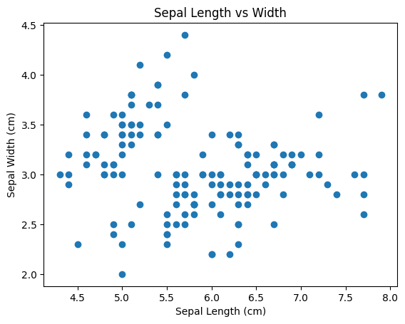

```python
# prompt: 'DataFrame' object has no attribute 'sepal_length' .....# A simple scatter plot with Matplotlib
# ax = plt.axes()
# ax.scatter(data.sepal_length, data.sepal_width)
# # Label the axes
# ax.set(xlabel='Sepal Length (cm)',
#        ylabel='Sepal Width (cm)',
#        title='Sepal Length vs Width'); ...fix this error in the code...

# A simple scatter plot with Matplotlib
ax = plt.axes()
ax.scatter(data['sepal length (cm)'], data['sepal width (cm)'])
# Label the axes
ax.set(xlabel='Sepal Length (cm)',
       ylabel='Sepal Width (cm)',
       title='Sepal Length vs Width');
```

## Question 6

Make a histogram of any one of the four features. Label axes and title it as appropriate.

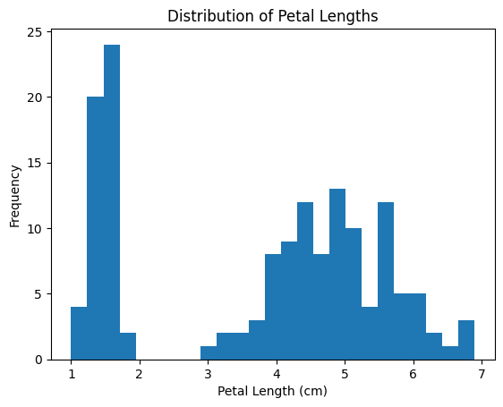

```python
# prompt: 'DataFrame' object has no attribute 'petal_length' ....fix this error in this code...# Using Matplotlib's plotting functionality
# ax = plt.axes()
# ax.hist(data.petal_length, bins=25);
# ax.set(xlabel='Petal Length (cm)',
#        ylabel='Frequency',
#        title='Distribution of Petal Lengths');

# The columns in the data DataFrame are now named according to the feature names from load_iris
# Use the correct column name 'petal length (cm)' instead of 'petal_length'

# Using Matplotlib's plotting functionality
ax = plt.axes()
ax.hist(data['petal length (cm)'], bins=25);
ax.set(xlabel='Petal Length (cm)',
       ylabel='Frequency',
       title='Distribution of Petal Lengths');
```

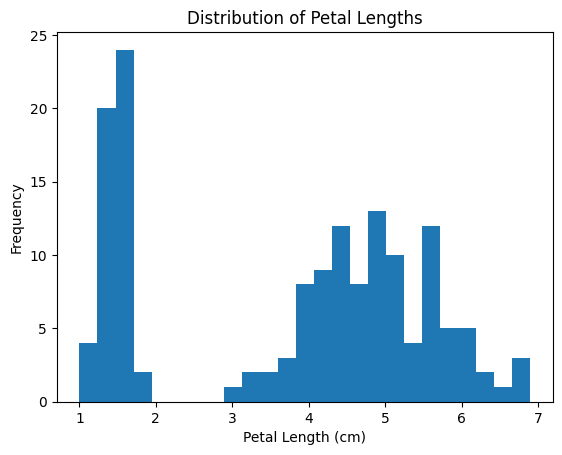

```python
# prompt: fix this error in this code 'DataFrame' object has no attribute 'petal_length'......# Alternatively using Pandas plotting functionality
# ax = data.petal_length.plot.hist(bins=25)
# ax.set(xlabel='Petal Length (cm)',
#        ylabel='Frequency',
#        title='Distribution of Petal Lengths');

# Alternatively using Pandas plotting functionality
ax = data['petal length (cm)'].plot.hist(bins=25)
ax.set(xlabel='Petal Length (cm)',
       ylabel='Frequency',
       title='Distribution of Petal Lengths');
```

## Question 7

Now create a single plot with histograms for each feature (`petal_width`, `petal_length`, `sepal_width`, `sepal_length`) overlayed. If you have time, next try to create four individual histogram plots in a single figure, where each plot contains one feature.

For some hints on how to do this with Pandas plotting methods, check out the [visualization guide](http://pandas.pydata.org/pandas-docs/version/0.18.1/visualization.html) for Pandas.

```python
try:
    import seaborn as sns

except:
    print('Seaborn must be installed for this course. Execute the following:')
    print('`conda install seaborn`')
    print('from a terminal and restart the kernel.')
```

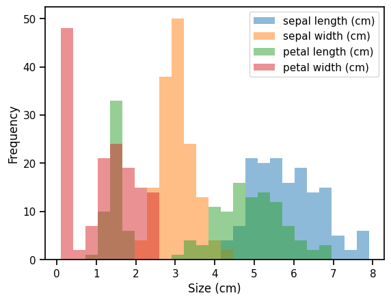

```python
sns.set_context('notebook')

# This uses the `.plot.hist` method
ax = data.plot.hist(bins=25, alpha=0.5)
ax.set_xlabel('Size (cm)');
```

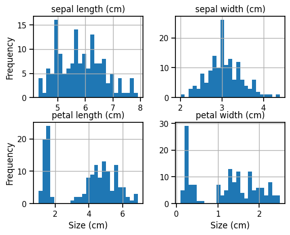

```python
# prompt: fix this error in the code # To create four separate plots, use Pandas `.hist` method
# axList = data.hist(bins=25)
# # Add some x- and y- labels to first column and last row
# for ax in axList.flatten():
#     if ax.is_last_row():
#         ax.set_xlabel('Size (cm)')
#     if ax.is_first_col():
#         ax.set_ylabel('Frequency') 'Axes' object has no attribute 'is_last_row'

# To create four separate plots, use Pandas `.hist` method
axList = data.hist(bins=25)

# Add some x- and y- labels to first column and last row
for row_idx, ax_row in enumerate(axList):
    for col_idx, ax in enumerate(ax_row):
        if row_idx == len(axList) - 1:  # Check if it's the last row
            ax.set_xlabel('Size (cm)')
        if col_idx == 0:  # Check if it's the first column
            ax.set_ylabel('Frequency')
```

## Question 8

Using Pandas, make a boxplot of each petal and sepal measurement. Here is the documentation for [Pandas boxplot method](http://pandas.pydata.org/pandas-docs/version/0.18.1/visualization.html#visualization-box).

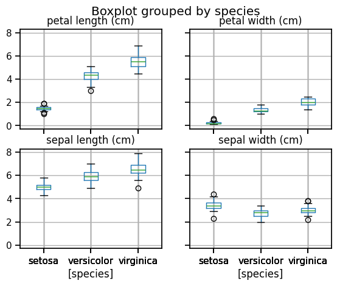

```python
# Pandas plotting functionality is pretty awesome!
# Here we have four separate plots

data.boxplot(by='species');
```

## Question 9

Now make a single boxplot where the features are separated in the x-axis and species are colored with different hues.

*Hint:* you may want to check the documentation for [Seaborn boxplots](http://seaborn.pydata.org/generated/seaborn.boxplot.html).

Also note that Seaborn is very picky about data format--for this plot to work, the input dataframe will need to be manipulated so that each row contains a single data point (a species, a measurement type, and the measurement value). Check out Pandas [stack](http://pandas.pydata.org/pandas-docs/stable/generated/pandas.DataFrame.stack.html) method as a starting place.

Here is an example of a data format that will work:

|  | species | measurement | size |
| --- | --- | --- | --- |
| 0 | setosa | sepal_length | 5.1 |
| 1 | setosa | sepal_width | 3.5 |

```python
# First we have to reshape the data so there is
# only a single measurement in each column

plot_data = (data
             .set_index('species')
             .stack()
             .to_frame()
             .reset_index()
             .rename(columns={0:'size', 'level_1':'measurement'})
            )

plot_data.head()
```

|  | species | measurement | size |
| --- | --- | --- | --- |
| 0 | setosa | sepal length (cm) | 5.1 |
| 1 | setosa | sepal width (cm) | 3.5 |
| 2 | setosa | petal length (cm) | 1.4 |
| 3 | setosa | petal width (cm) | 0.2 |
| 4 | setosa | sepal length (cm) | 4.9 |

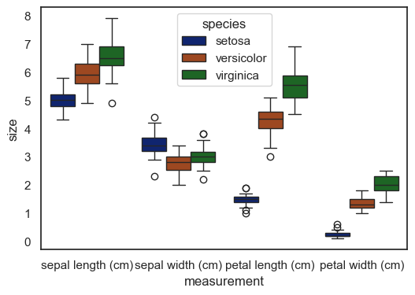

```python
# Now plot the dataframe from above using Seaborn

sns.set_style('white')
sns.set_context('notebook')
sns.set_palette('dark')

f = plt.figure(figsize=(6,4))
sns.boxplot(x='measurement', y='size',
            hue='species', data=plot_data);
```

## Question 10

Make a [pairplot](http://seaborn.pydata.org/generated/seaborn.pairplot.html) with Seaborn to examine the correlation between each of the measurements.

*Hint:* this plot may look complicated, but it is actually only a single line of code. This is the power of Seaborn and dataframe-aware plotting! See the lecture notes for reference.

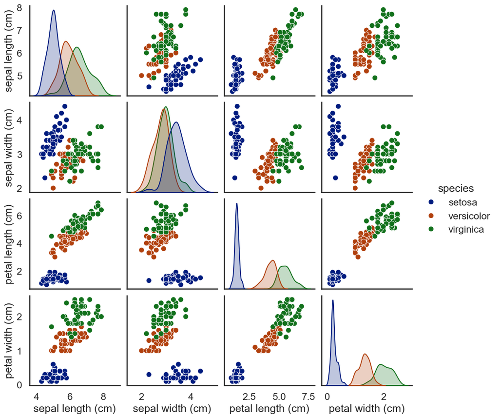

```python
sns.set_context('talk')
sns.pairplot(data, hue='species');
```